# HousePricesModel

**Big Data Intelligence**  
**Assignment 1**  
**House Prices [Kaggle Competition](https://www.kaggle.com/c/house-prices-advanced-regression-techniques) With Scikit-Learn, SKOPT and Optuna**

**Team Members**  
Jose Antonio Jijon Vorbeck - 100438045  
Didier Renzo Dirks - 100443386

In this assignment we will work with two different models to try to get the best model possible to be able to predict the selling prices of houses based on many given characteristics.

We are going to use Decision Trees and the K-Nearest-Neighbors models. Bus as we will show, the default parameters to get the best results out of these two models are not optimal. Therefore we will need to work on optimizing the model paramaters in a smar way to get the best results possible out of them.

```python
# imports
import pandas as pd
import numpy as np
import optuna
from scipy.stats import sem, uniform, expon, randint as sp_randint
import time
import matplotlib.pyplot as plt
import plotly.graph_objects as go

# Scikit-Learn
from sklearn import preprocessing, metrics, tree, neighbors
from sklearn.model_selection import train_test_split, RandomizedSearchCV, cross_val_score, KFold

# Scikit-Optimize
from skopt import BayesSearchCV
from skopt.space import Integer, Real, Categorical
import warnings
warnings.filterwarnings('ignore', message='The objective has been evaluated at this point before.')
optuna.logging.set_verbosity(optuna.logging.WARNING)
```

```python
# load and preprocess data
dataframe = pd.read_csv("kaggleCompetition.csv")
data = dataframe.values
X = data[0:1460,:-1]
y = data[0:1460,-1]
X_comp = data[1460:,:-1]  # <-- LEAVE UNTIL END, DONT USE
y_comp = data[1460:,-1]   # <-- LEAVE UNTIL END, DONT USE
print(f'Size of X matrix: {np.shape(X)}')
print(f'Size of y matrix: {np.shape(y)}')
print(f'Size of X_comp matrix: {np.shape(X_comp)}')
print(f'Size of y_comp matrix: {np.shape(y_comp)}')

# we see it is split in half
```

```
Size of X matrix: (1460, 79)
Size of y matrix: (1460,)
Size of X_comp matrix: (1459, 79)
Size of y_comp matrix: (1459,)
```

```python
# a first glance to the data
dataframe.head()
```

|  | MSSubClass | MSZoning | LotFrontage | LotArea | Street | Alley | LotShape | LandContour | Utilities | LotConfig | ... | PoolArea | PoolQC | Fence | MiscFeature | MiscVal | MoSold | YrSold | SaleType | SaleCondition | SalePrice |
| --- | --- | --- | --- | --- | --- | --- | --- | --- | --- | --- | --- | --- | --- | --- | --- | --- | --- | --- | --- | --- | --- |
| 0 | 60 | 4 | 65.0 | 8450 | 2 | 1 | 4 | 4 | 1 | 5 | ... | 0 | 1 | 3 | 3 | 0 | 2 | 2008 | 9 | 5 | 12.247694 |
| 1 | 20 | 4 | 80.0 | 9600 | 2 | 1 | 4 | 4 | 1 | 3 | ... | 0 | 1 | 3 | 3 | 0 | 5 | 2007 | 9 | 5 | 12.109011 |
| 2 | 60 | 4 | 68.0 | 11250 | 2 | 1 | 1 | 4 | 1 | 5 | ... | 0 | 1 | 3 | 3 | 0 | 9 | 2008 | 9 | 5 | 12.317167 |
| 3 | 70 | 4 | 60.0 | 9550 | 2 | 1 | 1 | 4 | 1 | 1 | ... | 0 | 1 | 3 | 3 | 0 | 2 | 2006 | 9 | 1 | 11.849398 |
| 4 | 60 | 4 | 84.0 | 14260 | 2 | 1 | 1 | 4 | 1 | 3 | ... | 0 | 1 | 3 | 3 | 0 | 12 | 2008 | 9 | 5 | 12.429216 |

5 rows × 80 columns

Standardization of the variables is a key step in the analysis

```python
scaler = preprocessing.StandardScaler().fit(X)
X = scaler.transform(X)
X_comp = scaler.transform(X_comp)
```

Splitting the data into training and testing sections

```python
X_train, X_test, y_train, y_test = train_test_split (X, y, train_size = 0.75, random_state = 0)
print(X_train.shape, y_train.shape)
print(X_test.shape, y_test.shape)
X_test.shape[0]/X.shape[0] #see that is is 25% of the whole data
```

```
(1095, 79) (1095,)
(365, 79) (365,)
```

```
0.25
```

### **3.1) Evaluate a DecisionTreeRegressor and a KNeighborsRegressor with default hyper-parameters.**

### Decision Tree Regression

We start by the decision tree here, working with the standard hyper-parameters.

```python
# DecisionTreeRegressor --> no arguments - default parameters
dtree = tree.DecisionTreeRegressor().fit(X_train, y_train)
```

```python
# K-Fold CV (2 Fold)

np.random.seed(0)
# create a k-fold cross validation iterator of k=2 folds
cv = KFold(n_splits=2, shuffle=True, random_state=0)
# The "minus" is because scikit maximizes scores, hence
# errors are negative
scores = -cross_val_score(dtree,
                         X_train, y_train,
                         scoring='neg_mean_squared_error',
                         cv = cv)

dt_default_mean = scores.mean()
# Printing the average score + Standard Deviation
print("Mean standard error: {0:.3f} (+/-{1:.3f})".format(dt_default_mean, sem(scores)))
```

```
Mean standard error: 0.055 (+/-0.001)
```

**K Neighbours Regression**

Now we proceed to do a regression with the standard parameters in KNeighborsRegressor()

```python
# K --> no arguments - default parameters
knn = neighbors.KNeighborsRegressor().fit(X_train, y_train)
```

```python
# K-Fold CV (2 Fold)

np.random.seed(0)
# create a k-fold cross validation iterator of k=10 folds
cv = KFold(n_splits=2, shuffle=True, random_state=0)
# The "minus" is because scikit maximizes scores, hence
# errors are negative
scores = -cross_val_score(knn, X_train, y_train,
                         scoring='neg_mean_squared_error',
                         cv = cv)

# Printing the average score + Standard Deviation
kn_default_mean = scores.mean()
print("Mean standard error: {0:.3f} (+/-{1:.3f})".format(kn_default_mean, sem(scores)))
```

```
Mean standard error: 0.037 (+/-0.001)
```

```python
pd.DataFrame([[dt_default_mean, kn_default_mean]], columns = ['Decision Tree', 'K-Neighbors'], index = ['Mean Square Error 2-CV'])
```

|  | Decision Tree | K-Neighbors |
| --- | --- | --- |
| Mean Square Error 2-CV | 0.054943 | 0.036703 |

### **3.2) Now, use random-search for tuning the following hyper-parameters of DecisionTreeRegressor:**

- min_samples_split: Scikit-learn uses a proportion that is a real number and ranges from 0.0 to 1.0.
- criterion {mse or friedman_mse}.
- max_depth: integer

Check the following web-page for info on the [hyper-parameters](https://scikit-learn.org/stable/modules/generated/sklearn.tree.DecisionTreeRegressor.html)

```python
# Search space
param_grid = {'max_depth': range(1,31),
              'min_samples_split': np.array(range(1,1001))/1000,
             'criterion': ["mse", "friedman_mse"]}

start = time.time()
np.random.seed(0)
dtree_random = RandomizedSearchCV(dtree,
                         param_grid,
                         scoring='neg_mean_squared_error',
                         cv=cv,
                         n_jobs=1, n_iter=20
                        )

dtree_random.fit(X = X_train, y = y_train)
dt_random_time = time.time() - start
```

```python
dtree_random_sum=dtree_random.best_params_
dtree_random_sum['time'] = round(dt_random_time,3)
dtree_random_sum['best score'] = round(-dtree_random.best_score_,7)
dtree_random_sum
```

```
{'min_samples_split': 0.044,
 'max_depth': 28,
 'criterion': 'friedman_mse',
 'time': 0.151,
 'best score': 0.0470302}
```

### **3.3) Use random-search for tuning the following KNN hyper-parameters:**

- n_neighbors: number of near neighbours to consider
- weights: (type of distance: euclidean or inverse euclidean)
- p: 1 or 2 (this is the exponent of the distance)

Check the following web-page for info on the [hyper-parameters](https://scikit-learn.org/stable/modules/generated/sklearn.neighbors.KNeighborsRegressor.html)

```python
# Search space
param_grid = {'n_neighbors': range(1,30),
              'p': [1,2],
             'weights': ["uniform", "distance"]}
start = time.time()

np.random.seed(0)
knn_random = RandomizedSearchCV(neighbors.KNeighborsRegressor(),
                         param_grid,
                         scoring='neg_mean_squared_error',
                         cv=cv,
                         n_jobs=1, n_iter=20
                        )

knn_random.fit(X = X_train, y = y_train)
knn_random_time = time.time()-start
```

```python
knn_random_sum = knn_random.best_params_
knn_random_sum['time'] = round(knn_random_time,3)
knn_random_sum['best score'] = round(-knn_random.best_score_,7)
knn_random_sum
```

```
{'weights': 'uniform',
 'p': 1,
 'n_neighbors': 7,
 'time': 1.526,
 'best score': 0.0322422}
```

### **3.4) Use now scikit-optimize (skopt) under the same conditions of 3.2-3.3. Use the same number of iterations or budget, so that you can draw some conclusions about what hyper-parameter tuning method obtains better results or is faster (or both).**

In this section we use the package **skopt** from scikit-learn to optimize the parameters in the best way possible.

**Decision Tree HPO**

```python
# Search space with integer uniform distributions
param_grid = {'max_depth': Integer(1,30),
              'min_samples_split': Real(low=0.01, high=1),
             'criterion': ["mse", "friedman_mse"]}
start = time.time()
np.random.seed(0)
dtree_bayesian = BayesSearchCV(tree.DecisionTreeRegressor(),
                    param_grid,
                    scoring='neg_mean_squared_error',
                    cv=cv,
                    n_jobs=1,
                    n_iter=20
                    )

dtree_bayesian.fit(X = X_train, y = y_train)
dt_bayes_time = time.time() - start
```

```python
dt_bayes_sum = dtree_bayesian.best_params_
dt_bayes_sum['time'] = round(dt_bayes_time,3)
dt_bayes_sum['best score'] = round(-dtree_bayesian.best_score_,7)
dt_bayes_sum
```

```
OrderedDict([('criterion', 'mse'),
             ('max_depth', 30),
             ('min_samples_split', 0.02194830476015583),
             ('time', 12.126),
             ('best score', 0.0478272)])
```

**K-Nearest Neighbors HPO**

```python
# Bayesian search for KNN
param_grid = {'n_neighbors': Integer(1,30),
              'p': Integer(1,2),
             'weights': ["uniform", "distance"]}
start = time.time()
np.random.seed(0)
knn_bayesian = BayesSearchCV(neighbors.KNeighborsRegressor(),
                         param_grid,
                         scoring='neg_mean_squared_error',
                         cv=cv,
                         n_jobs=1, n_iter=20
                        )

knn_bayesian.fit(X=X_train, y=y_train)
knn_bayes_time = time.time() - start
```

```python
knn_bayes_sum = knn_bayesian.best_params_
knn_bayes_sum['time']= round(knn_bayes_time,3)
knn_bayes_sum['best score'] = round(-knn_bayesian.best_score_,7)
knn_bayes_sum
```

```
OrderedDict([('n_neighbors', 12),
             ('p', 1),
             ('weights', 'distance'),
             ('time', 7.596),
             ('best score', 0.032386)])
```

### **3.5) Use now optuna under the same conditions of 3.3-3.4. Try to use the same computing power (iterations or budget). Please, read also 3.9) in the assignment, in case you want to develop this point further.**

**Decision Tree Regressor**

Below we can see the simplest approacch to using optuna as an optimization method for hyperparameters. We create an objective function to minimize. In this case, the negative of the mean square error is the objective to minimize, based on the hyperparameters max depth, min_samples_split and measure criterion. We give a suggestion to try to Optuna so that it creates a parameter grid to search for the optimal parameters.

```python
start = time.time()

def objective(trial):
    dtree_opt = tree.DecisionTreeRegressor(max_depth=trial.suggest_int("max_depth", 1, 30),
                                     min_samples_split=trial.suggest_float("min_samples_split", 0.0001, 1),
                                           criterion=trial.suggest_categorical('criterion',["mse", "friedman_mse"]))

    scores = -cross_val_score(dtree_opt, X_train, y_train,
                              scoring='neg_mean_squared_error',
                              n_jobs=1,
                              # Using again the same inner 2-folds for hyper-parameter tuning
                              cv=cv)
    return scores.mean()

np.random.seed(0)
dtree_optuna = optuna.create_study(direction="minimize")
dtree_optuna.optimize(objective, n_trials=20)

dt_optuna_time = time.time()-start
```

```python
dt_optuna_sum = dtree_optuna.best_params
dt_optuna_sum['time']= round(dt_optuna_time,3)
dt_optuna_sum['best score']= round(dtree_optuna.best_value,7)
# Summary of the optuna optimization results
dt_optuna_sum
```

```
{'max_depth': 15,
 'min_samples_split': 0.04969413960390612,
 'criterion': 'mse',
 'time': 0.205,
 'best score': 0.0447831}
```

Optuna has very interesting visualizations, to help us understand the choosing methodology that it goes through. The next graph shows the history plot with the 20 iterations and their results. We can see that the results tend to go down with every iteration, but we see that after the 11th iteration it has no big changes anymore.

```python
optuna.visualization.plot_optimization_history(dtree_optuna)
```

[interactive chart not shown]

```python
optuna.visualization.plot_slice(dtree_optuna)
```

[interactive chart not shown]

Now we apply the same simple optimization algorithm for the KNN method. The appraocch in this case is the same, but the paramaters are the ones corresponding to the model chosen.

**K-Nearest Neighbors**

```python
start = time.time()

def objective(trial):
    knn_opt = neighbors.KNeighborsRegressor(n_neighbors=trial.suggest_int("n_neighbors", 1, 30),
                                         p=trial.suggest_int("p", 1, 2),
                                           weights=trial.suggest_categorical('weights',["distance", "uniform"]))

    scores = -cross_val_score(knn_opt, X_train, y_train,
                              scoring='neg_mean_squared_error',
                              n_jobs=1,
                              cv=cv)
    return scores.mean()

np.random.seed(5)
knn_optuna = optuna.create_study(direction="minimize")
knn_optuna.optimize(objective, n_trials=20)

knn_optuna_time = time.time() - start
```

```python
knn_optuna_sum = knn_optuna.best_params
knn_optuna_sum['time']= round(knn_optuna_time,3)
knn_optuna_sum['best score'] = round(knn_optuna.best_value,7)
knn_optuna_sum
```

[output not shown]

Again, here we see the history plot showing the evolution of the objective value across the iterations.

```python
optuna.visualization.plot_optimization_history(knn_optuna)
```

[interactive chart not shown]

```python
optuna.visualization.plot_slice(knn_optuna)
```

[interactive chart not shown]

### Combined Optimization

Finally, Optuna also allows us to do a combined optimization using both models as extra parameters to compute. Meaning that the type of model (KNN or Decision Tree) are also parameters from which the optimization process will choose, and optuna will tell us which is the best model overall.

This is a very nice and useful characteristic, since this way we don't need to evaluate each model separately, and we could rely on this optimization for the model selection and hyper-parameter tunning at the same time.

```python
start = time.time()
def objective(trial):
    classifier_name = trial.suggest_categorical('classifier', ['DTree', 'KNN'])

    # depending on the model chosen, we must choose the HP
    if classifier_name == 'DTree':
        classifier_obj = tree.DecisionTreeRegressor(max_depth=trial.suggest_int("max_depth", 1, 30),
                                    min_samples_split=trial.suggest_uniform("min_samples_split", 0.0, 1.0),
                                    criterion=trial.suggest_categorical('criterion',["mse", "friedman_mse"]))
    else:
        classifier_obj = neighbors.KNeighborsRegressor(n_neighbors=trial.suggest_int("n_neighbors", 1, 30),
                                            p=trial.suggest_int("p", 1, 2),
                                            weights=trial.suggest_categorical('weights',["distance", "uniform"]))

    scores = -cross_val_score(classifier_obj, X_train, y_train,
                              scoring='neg_mean_squared_error',
                              n_jobs=1,
                              cv=cv)
    return scores.mean()

np.random.seed(5)
join_optuna = optuna.create_study(direction="minimize")
join_optuna.optimize(objective, n_trials=20)
join_optuna_time = time.time() - start
```

```python
join_optuna_sum = join_optuna.best_params
join_optuna_sum['time']= round(join_optuna_time,3)
join_optuna_sum['best score'] = round(join_optuna.best_value,7)
join_optuna_sum
```

[output not shown]

Below the history plot of the objective function is shown.

```python
optuna.visualization.plot_optimization_history(join_optuna)
```

[interactive chart not shown]

In this case we see that the parameters are the parameters for the KNN and the DT models, plus the model itself, adding to seven different parameters from which optuna chooses the optimum case.

```python
optuna.visualization.plot_slice(join_optuna)
```

[interactive chart not shown]

### **3.6) Determine now what is your best method according to their inner evaluation. You can also draw some conclusions: has hyper-parameter tuning being able to improve KNN and/or Decision Trees? What HPO method is best? What HPO method is faster?**

We can see that there is the default hyperparameters set by the scikit-learn models that do not work optimally in every ocasion. Therefore, we must try to optimize the hyperparameters to get more accurate results and better predictions.

*To this end, there are three main methods in which to set the hyperparameters.*

- The first option is to use a random search cross-validation method to randomly vary the data and try to get better parameters. This is done in sections 3.2 and 3.3.
- The second method is by using the scikit-optimize (skopt) package to generate a Corss-Vaidation bayesian method to find the most optimal parameters. Section 3.4 describes the process.
- The third method, the most innovative one, is the Optuna HPO method. This is done with help of the optuna package used in section 3.5.

Now that we have concluded all the optimization methods, we can compare them in terms of the Hyperparameters chosen, the ellapsed time and the score they receive when doing the cross-validation techniques.

```python
DecisionTree_Sum = {'Random':dtree_random_sum, 'Bayesian (SKOPT)':dt_bayes_sum, 'Optuna': dt_optuna_sum}
KNN_Sum = {'Random':knn_random_sum, 'Bayesian (SKOPT)':knn_bayes_sum, 'Optuna': knn_optuna_sum, 'Joint Optuna': join_optuna_sum}
```

We can see below the comparisson table between the different HPO methods.

### Summary table of Decision Tree Model

```python
pd.DataFrame.from_dict(DecisionTree_Sum)
```

|  | Random | Bayesian (SKOPT) | Optuna |
| --- | --- | --- | --- |
| min_samples_split | 0.044 | 0.0219483 | 0.0496941 |
| max_depth | 28 | 30 | 15 |
| criterion | friedman_mse | mse | mse |
| time | 0.151 | 12.126 | 0.205 |
| best score | 0.0470302 | 0.0478272 | 0.0447831 |

### Summary table for KNN model

```python
pd.DataFrame.from_dict(KNN_Sum)
```

|  | Random | Bayesian (SKOPT) | Optuna | Joint Optuna |
| --- | --- | --- | --- | --- |
| weights | uniform | distance | distance | distance |
| p | 1 | 1 | 1 | 1 |
| n_neighbors | 7 | 12 | 7 | 6 |
| time | 1.526 | 7.596 | 1.461 | 1.194 |
| best score | 0.0322422 | 0.032386 | 0.031361 | 0.0313905 |
| classifier | NaN | NaN | NaN | KNN |

For the case of the KNN model, we see that in general, the results of the best score (MSE) are better than those from the decision tree. The difference is significant.

We can also see that the parameters between the 3 HPO are quite different, while the weights is measured in the 'distance' way for both Bayesian and Optuna, the random model chooses the 'uniform' weights.

The number of neighbors considered is also different, since both Optuna and Random have selected 7 neighbors to be optimal, the Bayesian approach has decided that 12 neighbors is better.

Finally, in terms of the errors, we see that the model with the better inner evalutaion predictions is the Optuna model, with a final score of 0.031.

Below we can see a summary table with all the scores of the different models and their HPO methods. We see that the best overall score is performed by the Optuna HPO method in the KNN model.

```python
scores_sum = pd.DataFrame([[dt_default_mean, kn_default_mean], [-dtree_random.best_score_, -knn_random.best_score_],[-dtree_bayesian.best_score_, -knn_bayesian.best_score_],[dtree_optuna.best_value, knn_optuna.best_value]], columns = ['Decision Tree', 'K-Neighbors'], index = ['Default HP', 'Random', 'Bayesian(SKOPT)', 'Optuna']).rename_axis('Minimal Mean Square Error 2-CV', axis=1)
scores_sum
```

| Minimal Mean Square Error 2-CV | Decision Tree | K-Neighbors |
| --- | --- | --- |
| Default HP | 0.054943 | 0.036703 |
| Random | 0.047030 | 0.032242 |
| Bayesian(SKOPT) | 0.047827 | 0.032386 |
| Optuna | 0.044783 | 0.031361 |

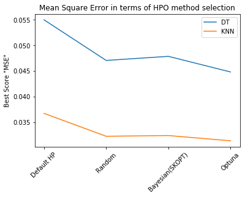

```python
plt.plot(scores_sum['Decision Tree'], label = 'DT')
plt.plot(scores_sum['K-Neighbors'], label = 'KNN')
plt.ylabel('Best Score "MSE"')
plt.title('Mean Square Error in terms of HPO method selection')
plt.legend(loc = 'upper right')
plt.xticks(rotation=45)
plt.show()
```

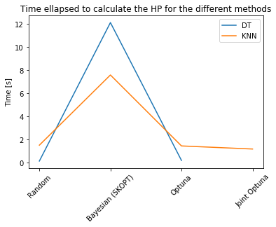

```python
plt.plot(pd.DataFrame.from_dict(DecisionTree_Sum).loc["time"] , label = 'DT')
plt.plot(pd.DataFrame.from_dict(KNN_Sum).loc['time'], label = 'KNN')
plt.ylabel('Time [s]')
plt.title('Time ellapsed to calculate the HP for the different methods')
plt.legend(loc = 'upper right')
plt.xticks(rotation=45)
plt.show()
```

It is very interesting to see the time ellapsed for the different models. We can see that for both KNN and DT, the Optuna methodology takes very little time, while the fastest method is the one for the random search for the decision tree model, although we see that its MSE is not the best.

It is important to notice the time it takes for the joint-optuna HPO method, since this one deals with both models at the same time and delivers the best one, and in shorter time than the Bayesian method provided by SKOPT, which is the method that takes the longest, in all cases.

**Best Model**

As seen in the results and throughout the discussion, the model that delivers a better mean square error is the KNN one obtained with Optuna. This model was also selected as the best one when using the Joint method with Optuna.

The following properties are printed below:

```python
knn_optuna_sum
```

```
{'n_neighbors': 7,
 'p': 1,
 'weights': 'distance',
 'time': 1.461,
 'best score': 0.031361}
```

### **3.7) Now, make an estimation of the performance you will get at the competition. This involves evaluating the selected model on (Xtest, ytest)) partition, that was excised at the beginning just for this purpose.**

```python
# Predict y_train with the x_train data using the final model
# This should be very good as we used this data to train our model

FINAL_MODEL = neighbors.KNeighborsRegressor(**knn_optuna.best_params)
FM_train = FINAL_MODEL.fit(X_train,y_train)
y_train_pred = FM_train.predict(X_train)

# Predict y_test with the x_test data using the final model
# This should be less good as the model has never seen this data before
y_test_pred = FINAL_MODEL.predict(X_test)

# The first score should be very small here, while the second will probably be bigger
print(f'MSE of the train data:  {metrics.mean_squared_error(y_train, y_train_pred)}')
print(f'MSE of the test data: {metrics.mean_squared_error(y_test, y_test_pred)}')

# The kaggle competition shows results based on the root mean squared error, thats why we show this:
print(f'RMSE of the test data: {np.sqrt(metrics.mean_squared_error(y_test, y_test_pred))}')
```

```
MSE of the train data:  0.0
MSE of the test data: 0.02625784871924517
RMSE of the test data: 0.16204273732335298
```

### **3.8) Then train the final model using the selected method on the whole available data (X,y) and use it to make predictions on Xcomp. Register to the competition, send your predictions, and obtain a screenshot of the place (rank) you got at the competition.**

```python
# Train the best final model on the whole X (instead of just x_train)
FM_Final = FINAL_MODEL.fit(X,y)

FM_Results = FM_Final.predict(X_comp)

def predictions2df(a):
    df = pd.DataFrame(np.exp(a), index=range(1461, 2920), columns=['SalePrice'])
    df.index = df.index.rename("Id")
    return df
predictions2df(FINAL_MODEL.predict(X_comp)).head()

# To export to CSV
# predictions2df(FINAL_MODEL.predict(X_comp)).to_csv('final_comp_results.csv')
```

| Id | SalePrice |
| --- | --- |
| 1461 | 122612.699154 |
| 1462 | 143520.791699 |
| 1463 | 183218.171151 |
| 1464 | 195924.164875 |
| 1465 | 188769.649559 |

Finnaly, below we can see the screen shots of the results in Kaggle.

[figure not shown]

### **3.9) These points are reserved for using optuna beyond what I have explained, and it should be an original contribution from the student. For instance, using Optuna plot utilities to visualize the search and draw conclusions. Or exploring the hyper-parameter space in more complex ways. Etc.**

Optuna was used in depth in part 3.5, where we have used all the visualization techniques like the Optimization History Plot that shows the progress of the objetive function score with respect to every iteration, and the Slice plot, that shows one graph per parameter and the values chosen for a specific iteration. We also used a joint method to compare both methods and select the optimum one.